# Отчёт по лабораторной работе №6

Реализация основных моделей в подходе сетей Петри

Автор

принадлежность

Малюга Валерия Васильевна

Российский университет дружбы народов

# 1 Цель работы

1. Реализовать модель эпидемии SIR с помощью сетей Петри.
2. Провести детерминированную (ODE) и стохастическую (алгоритм Гиллеспи) симуляции.
3. Исследовать влияние коэффициента заражения $\beta$ на динамику эпидемии.
4. Создать анимацию эпидемического процесса.
5. Преобразовать код в литературный стиль и сгенерировать производные форматы.
6. Подготовить отчёт с графиками, анимацией и встроенной документацией.

# 2 Задание

1. Создать рабочий каталог для кода, установить необходимые пакеты Julia.
2. Реализовать модуль `SIRPetri.jl` с функциями построения сети, симуляции и визуализации.
3. Выполнить базовый прогон, сохранить данные и построить графики.
4. Провести параметрическое сканирование $\beta$, визуализировать зависимость пика заболеваемости и итоговой доли выздоровевших.
5. Создать анимацию детерминированной динамики.
6. Сгенерировать итоговые сравнительные графики.
7. Преобразовать код в литературный стиль, сгенерировать чистые скрипты, Jupyter-ноутбуки и Quarto-документы с помощью `tangle.jl`.
8. Выполнить код в Jupyter-ноутбуках, интегрировать результаты в отчёт.

# 3 Теоретическое введение

## 3.1 Сети Петри

Сеть Петри — математический аппарат для моделирования дискретных систем, предложенный Карлом Адамом Петри в 1962 году [1]. Она представляет собой двудольный ориентированный граф с двумя типами вершин:

- *позиции* (places) — пассивные элементы, описывающие состояние системы (содержат фишки — маркеры);
- *переходы* (transitions) — активные элементы, моделирующие события.

Дуги соединяют позиции и переходы, показывая, какие условия необходимы для срабатывания событий и как изменяется состояние после их наступления. Текущее распределение фишек по позициям называется *маркировкой*. Срабатывание разрешённого перехода приводит к мгновенному изменению маркировки.

Формально сеть Петри задаётся четвёркой $N = (P, T, F, M_0)$, где $P$ — множество позиций, $T$ — множество переходов, $F \subseteq (P \times T) \cup (T \times P)$ — множество дуг, $M_0: P \to \mathbb{N}$ — начальная маркировка [2].

## 3.2 Модель SIR

Модель SIR (Susceptible–Infected–Recovered) — классическая компартментальная модель эпидемиологии, предложенная Кермаком и Маккендриком в 1927 году [3]. Популяция разделяется на три группы:

- $S$ — восприимчивые,
- $I$ — инфицированные,
- $R$ — выздоровевшие (приобретшие иммунитет или умершие).

Динамика описывается системой обыкновенных дифференциальных уравнений:

$$\begin{aligned}
\frac{dS}{dt} &= -\beta S I,\\
\frac{dI}{dt} &= \beta S I - \gamma I,\\
\frac{dR}{dt} &= \gamma I,
\end{aligned}$$

где $\beta$ — коэффициент заражения (infection rate), $\gamma$ — скорость выздоровления (recovery rate). Базовое репродуктивное число $R_0 = \beta / \gamma$ определяет, возникнет ли эпидемия ($R_0 > 1$) или затухнет ($R_0 < 1$).

## 3.3 Представление модели SIR сетью Петри

В данной работе модель реализована с помощью двух переходов:

- `infection`: $S + I \to I + I$ (скорость $\beta$),
- `recovery`: $I \to R$ (скорость $\gamma$).

Начальная маркировка: $S = 990$, $I = 10$, $R = 0$. Соответствующая сеть Петри создаётся в модуле `SIRPetri.jl` с использованием пакета `AlgebraicPetri`.

Для симуляции используются: - детерминированный подход — решение ОДУ методом Tsit5 (пакет `OrdinaryDiffEq`); - стохастический подход — прямой метод Гиллеспи (Stochastic Simulation Algorithm), реализованный вручную.

# 4 Выполнение лабораторной работы

## 4.1 Подготовка рабочего пространства

В каталоге `lab06` был создан проект DrWatson, активированы необходимые пакеты: `AlgebraicPetri`, `Catlab`, `OrdinaryDiffEq`, `Plots`, `DataFrames`, `CSV`, `Random`, `Literate`, `IJulia`. Код модуля сохранён в `src/SIRPetri.jl`.

## 4.2 Базовый прогон модели SIR

Запущен скрипт `sirpetri_run.jl` с параметрами $\beta = 0.3$, $\gamma = 0.1$, $T = 100$. Выполнены детерминированная и стохастическая симуляции, результаты сохранены в файлы `sir_det.csv` и `sir_stoch.csv`.

Полученные графики динамики численности групп представлены на рис. 1 и 2.

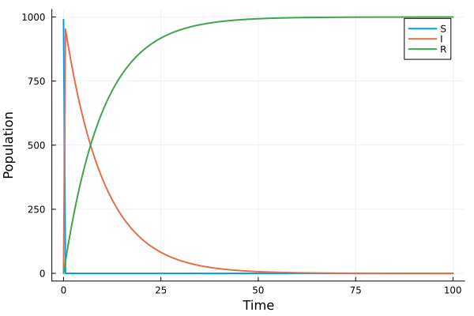

Рисунок 1: Детерминированная динамика SIR

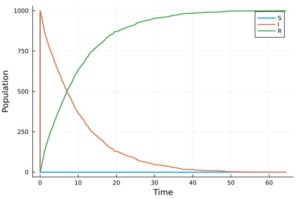

Рисунок 2: Стохастическая динамика SIR

Стохастическая траектория демонстрирует небольшие флуктуации, но сохраняет общую форму, близкую к детерминированной кривой, что ожидаемо при большом размере популяции.

## 4.3 Исследование влияния параметра $\beta$

Скрипт `sirpetri_scan_parameters.jl` провёл серию детерминированных симуляций для $\beta$ от $0.1$ до $0.8$ с шагом $0.05$ при фиксированном $\gamma = 0.1$. Для каждого значения вычислены пик инфицированных $I_{\max}$ и конечная доля выздоровевших $R(\infty)$. Результаты сохранены в `sir_scan.csv` и визуализированы на рис. 3.

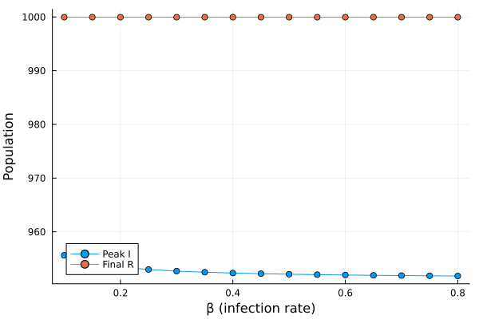

Рисунок 3: Зависимость пика $I$ и конечного $R$ от $\beta$

## 4.4 Анимация эпидемического процесса

Скрипт `sirpetri_animate.jl` создал анимацию изменения численности групп $S, I, R$ во времени. Анимация сохранена как `sir_animation.gif`.

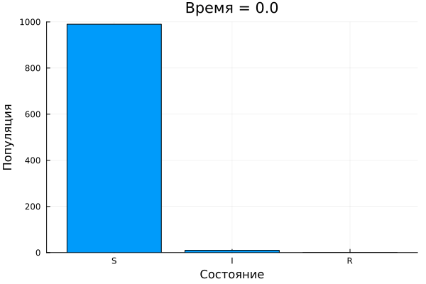

Рисунок 4: Анимация динамики SIR

## 4.5 Итоговые сравнительные графики

Скрипт `sirpetri_report.jl` загрузил сохранённые данные и построил два отчётных графика: сравнение детерминированной и стохастической кривых $I(t)$ (рис. 5) и зависимость пика $I$ от $\beta$ (рис. 6).

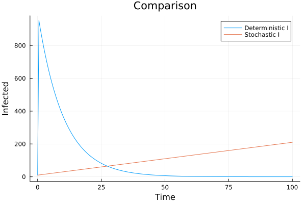

Рисунок 5: Сравнение детерминированной и стохастической $I(t)$

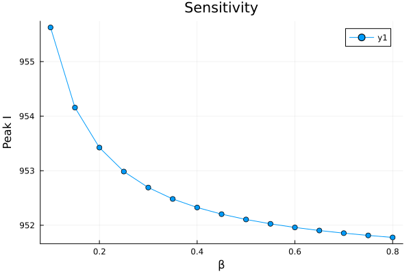

Рисунок 6: Чувствительность пика $I$ к $\beta$

## 4.6 Преобразование в литературный стиль и генерация производных форматов

Исходные скрипты были дополнены описательным текстом в духе литературного программирования (Literate.jl). С помощью универсального скрипта `tangle.jl` из каждого литературного файла были сгенерированы:

- чистый исполняемый скрипт,
- документ Quarto (`.qmd`),
- Jupyter-ноутбук (`.ipynb`).

Все сгенерированные Jupyter-ноутбуки были проверены на выполнимость, графики и анимация отображаются корректно.

## 4.7 Реализация скриптов

Ниже представлены Quarto-документы, сгенерированные из литературных скриптов модели SIR с сетями Петри.

### 4.7.1 Базовый прогон модели SIR (сети Петри)

**Цель**: выполнить детерминированную (ODE) и стохастическую (алгоритм Гиллеспи) симуляции эпидемии SIR с параметрами по умолчанию, сохранить результаты в `data/` и показать графики.

#### 4.7.1.1 Инициализация проекта

```julia
using DrWatson
@quickactivate "project"
using Random
include(srcdir("SIRPetri.jl"))
using .SIRPetri
using DataFrames, CSV, Plots
```

#### 4.7.1.2 Параметры эксперимента

```julia
β = 0.3   # коэффициент заражения
γ = 0.1   # коэффициент выздоровления
tmax = 100.0  # длительность симуляции
```

```
100.0
```

#### 4.7.1.3 Построение сети Петри

```julia
net, u0, states = build_sir_network(β, γ)
```

```
(AlgebraicPetri.LabelledPetriNet:
  T = 1:2
  S = 1:3
  I = 1:3
  O = 1:3
  Name = 1:0
  it : I → T = [1, 1, 2]
  is : I → S = [1, 2, 2]
  ot : O → T = [1, 1, 2]
  os : O → S = [2, 2, 3]
  tname : T → Name = [:infection, :recovery]
  sname : S → Name = [:S, :I, :R], [990.0, 10.0, 0.0], [:S, :I, :R])
```

#### 4.7.1.4 Детерминированная симуляция

```julia
df_det = simulate_deterministic(net, u0, (0.0, tmax); saveat=0.5, rates=[β, γ])
CSV.write(datadir("sir_det.csv"), df_det)
```

```
"/home/vvmalyuga/work/study/2026-1/2026-1--study--simulation-modeling/labs/lab06/data/sir_det.csv"
```

#### 4.7.1.5 Стохастическая симуляция

```julia
Random.seed!(123)  # фиксируем генератор для воспроизводимости
df_stoch = simulate_stochastic(net, u0, (0.0, tmax); rates=[β, γ])
CSV.write(datadir("sir_stoch.csv"), df_stoch)
```

```
"/home/vvmalyuga/work/study/2026-1/2026-1--study--simulation-modeling/labs/lab06/data/sir_stoch.csv"
```

#### 4.7.1.6 Визуализация

```
Could not create decoration from factory! Running with no decorations.
```

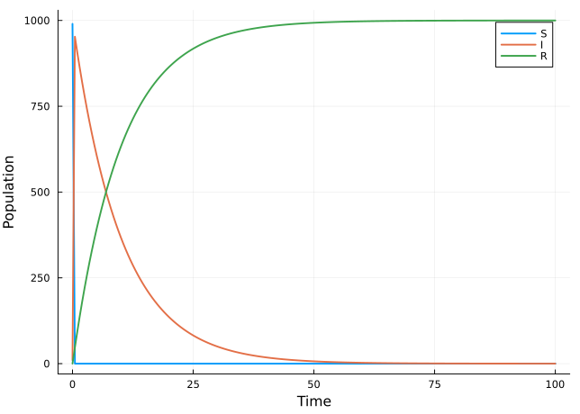

```julia
p_det = plot_sir(df_det)
savefig(plotsdir("sir_det_dynamics.png"))
if isinteractive()
    display(p_det)
end
p_det
```

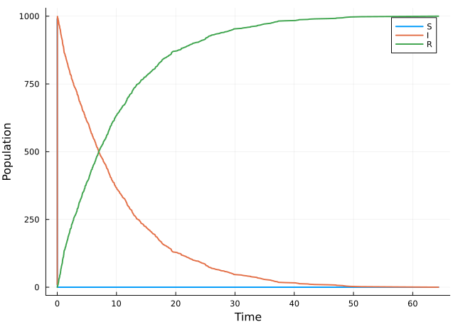

```julia
p_stoch = plot_sir(df_stoch)
savefig(plotsdir("sir_stoch_dynamics.png"))
if isinteractive()
    display(p_stoch)
end
p_stoch
```

```julia
println("Базовый прогон завершён. Результаты в data/ и plots/")
```

```
Базовый прогон завершён. Результаты в data/ и plots/
```

### 4.7.2 Сканирование коэффициента заражения β в модели SIR (сети Петри)

**Цель**: исследовать влияние β на пик заболеваемости и итоговое число переболевших. Проводится серия детерминированных симуляций для значений β от 0.1 до 0.8 с шагом 0.05. График зависимости показан в ноутбуке.

#### 4.7.2.1 Инициализация

```julia
using DrWatson
@quickactivate "project"
include(srcdir("SIRPetri.jl"))
using .SIRPetri
using DataFrames, CSV, Plots
```

[output not shown]

#### 4.7.2.2 Параметры сканирования

```julia
β_range = 0.1:0.05:0.8
γ_fixed = 0.1
tmax = 100.0
```

```
100.0
```

#### 4.7.2.3 Цикл по β

```julia
results = []
for β in β_range
    net, u0, _ = build_sir_network(β, γ_fixed)
    df = simulate_deterministic(net, u0, (0.0, tmax); saveat=0.5, rates=[β, γ_fixed])
    peak_I = maximum(df.I)
    final_R = df.R[end]
    push!(results, (β = β, peak_I = peak_I, final_R = final_R))
end
```

#### 4.7.2.4 Сохранение таблицы результатов

```julia
df_scan = DataFrame(results)
CSV.write(datadir("sir_scan.csv"), df_scan)
```

```
"/home/vvmalyuga/work/study/2026-1/2026-1--study--simulation-modeling/labs/lab06/data/sir_scan.csv"
```

#### 4.7.2.5 График зависимости пика I и конечного R от β

```
Сканирование β завершено. Результат в data/sir_scan.csv
```

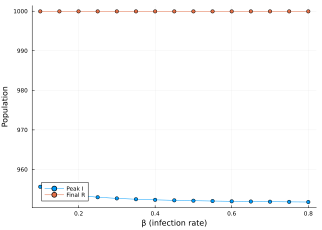

```julia
p = plot(
    df_scan.β,
    [df_scan.peak_I df_scan.final_R],
    label = ["Peak I" "Final R"],
    marker = :circle,
    xlabel = "β (infection rate)",
    ylabel = "Population",
)
savefig(plotsdir("sir_scan.png"))
if isinteractive()
    display(p)
end
println("Сканирование β завершено. Результат в data/sir_scan.csv")
p
```

### 4.7.3 Анимация детерминированной динамики SIR

**Цель**: создать GIF-анимацию, показывающую изменение количества восприимчивых (S), инфицированных (I) и выздоровевших (R) во времени. В ноутбуке анимация будет показана автоматически.

#### 4.7.3.1 Инициализация

```julia
using DrWatson
@quickactivate "project"
include(srcdir("SIRPetri.jl"))
using .SIRPetri
using Plots
```

[output not shown]

#### 4.7.3.2 Параметры

```julia
β = 0.3
γ = 0.1
tmax = 100.0
```

```
100.0
```

#### 4.7.3.3 Детерминированная симуляция с частым сохранением для плавности

```julia
net, u0, _ = build_sir_network(β, γ)
df = simulate_deterministic(net, u0, (0.0, tmax); saveat=0.2, rates=[β, γ])
```

501×4 DataFrame

476 rows omitted

| Row | time Float64 | S Float64 | I Float64 | R Float64 |
| --- | --- | --- | --- | --- |
| 1 | 0.0 | 990.0 | 10.0 | 0.0 |
| 2 | 0.2 | -7.34291e-8 | 981.705 | 18.2949 |
| 3 | 0.4 | 4.52843e-7 | 962.266 | 37.7339 |
| 4 | 0.6 | -4.4882e-8 | 943.212 | 56.7881 |
| 5 | 0.8 | 2.37544e-8 | 924.535 | 75.4649 |
| 6 | 1.0 | 3.28252e-7 | 906.228 | 93.7719 |
| 7 | 1.2 | 7.70776e-9 | 888.284 | 111.716 |
| 8 | 1.4 | -1.06965e-7 | 870.694 | 129.306 |
| 9 | 1.6 | 4.76025e-7 | 853.453 | 146.547 |
| 10 | 1.8 | -4.08603e-7 | 836.554 | 163.446 |
| 11 | 2.0 | -2.6597e-7 | 819.989 | 180.011 |
| 12 | 2.2 | -4.02436e-7 | 803.752 | 196.248 |
| 13 | 2.4 | 2.49118e-7 | 787.837 | 212.163 |
| ⋮ | ⋮ | ⋮ | ⋮ | ⋮ |
| 490 | 97.8 | 2.03786e-12 | 0.0566647 | 999.943 |
| 491 | 98.0 | 2.03102e-12 | 0.0555434 | 999.944 |
| 492 | 98.2 | 2.02433e-12 | 0.0544441 | 999.946 |
| 493 | 98.4 | 2.01779e-12 | 0.0533665 | 999.947 |
| 494 | 98.6 | 2.01141e-12 | 0.0523101 | 999.948 |
| 495 | 98.8 | 2.00517e-12 | 0.0512745 | 999.949 |
| 496 | 99.0 | 1.99907e-12 | 0.0502593 | 999.95 |
| 497 | 99.2 | 1.99311e-12 | 0.0492641 | 999.951 |
| 498 | 99.4 | 1.98729e-12 | 0.0482886 | 999.952 |
| 499 | 99.6 | 1.98159e-12 | 0.0473324 | 999.953 |
| 500 | 99.8 | 1.97603e-12 | 0.0463952 | 999.954 |
| 501 | 100.0 | 1.97059e-12 | 0.0454765 | 999.955 |

#### 4.7.3.4 Создание анимации

[output not shown]

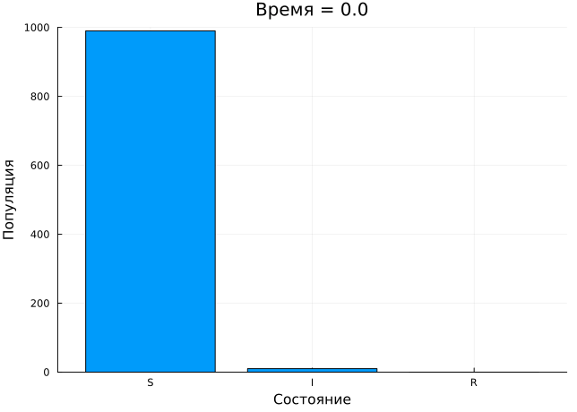

```julia
anim = @animate for row in eachrow(df)
    bar(["S", "I", "R"], [row.S, row.I, row.R],
        legend = false,
        ylims = (0, 1000),
        xlabel = "Состояние",
        ylabel = "Популяция",
        title = "Время = $(round(row.time, digits=1))"
    )
end

gif(anim, plotsdir("sir_animation.gif"), fps = 10)
```

#### 4.7.3.5 Отображение анимации в ноутбуке

```julia
if isinteractive()
    try
        using IJulia  # доступен внутри Jupyter
        display("image/gif", read(plotsdir("sir_animation.gif")))
    catch e
        @warn "Не удалось отобразить анимацию в ноутбуке: $e"
    end
end

println("Анимация сохранена в plots/sir_animation.gif")
```

```
Анимация сохранена в plots/sir_animation.gif
```

### 4.7.4 Итоговый отчёт по модели SIR (сети Петри)

**Цель**: построить сравнительные графики, используя ранее сохранённые результаты: сравнение детерминированной и стохастической динамики инфицированных, а также зависимость пика I от β. Все графики будут показаны в ноутбуке.

#### 4.7.4.1 Загрузка данных

```julia
using DrWatson
@quickactivate "project"
using DataFrames, CSV, Plots

df_det = CSV.read(datadir("sir_det.csv"), DataFrame)
df_stoch = CSV.read(datadir("sir_stoch.csv"), DataFrame)
df_scan = CSV.read(datadir("sir_scan.csv"), DataFrame)
```

15×3 DataFrame

| Row | β Float64 | peak_I Float64 | final_R Float64 |
| --- | --- | --- | --- |
| 1 | 0.1 | 955.626 | 999.954 |
| 2 | 0.15 | 954.157 | 999.954 |
| 3 | 0.2 | 953.424 | 999.954 |
| 4 | 0.25 | 952.984 | 999.955 |
| 5 | 0.3 | 952.691 | 999.955 |
| 6 | 0.35 | 952.482 | 999.955 |
| 7 | 0.4 | 952.326 | 999.955 |
| 8 | 0.45 | 952.204 | 999.955 |
| 9 | 0.5 | 952.106 | 999.955 |
| 10 | 0.55 | 952.026 | 999.955 |
| 11 | 0.6 | 951.96 | 999.955 |
| 12 | 0.65 | 951.904 | 999.955 |
| 13 | 0.7 | 951.856 | 999.955 |
| 14 | 0.75 | 951.814 | 999.955 |
| 15 | 0.8 | 951.777 | 999.955 |

#### 4.7.4.2 Сравнение детерминированной и стохастической динамики I(t)

```
Could not create decoration from factory! Running with no decorations.
```

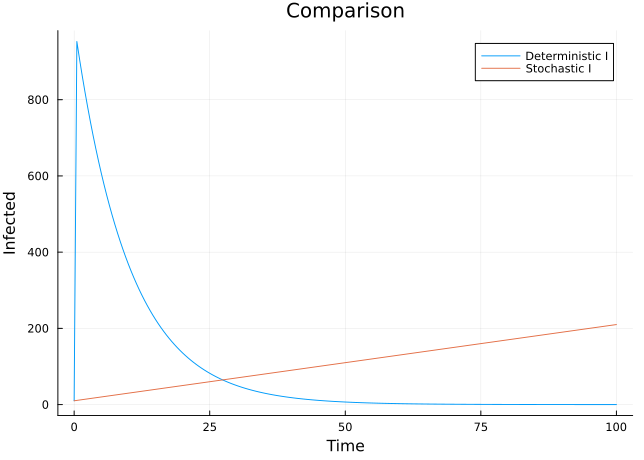

```julia
p1 = plot(
    df_det.time,
    [df_det.I df_stoch.I[1:length(df_det.time)]],
    label = ["Deterministic I" "Stochastic I"],
    xlabel = "Time",
    ylabel = "Infected",
    title = "Comparison",
)
savefig(plotsdir("comparison.png"))
if isinteractive()
    display(p1)
end
p1
```

#### 4.7.4.3 Чувствительность: пик I от β

```
Отчётные графики сохранены в plots/
```

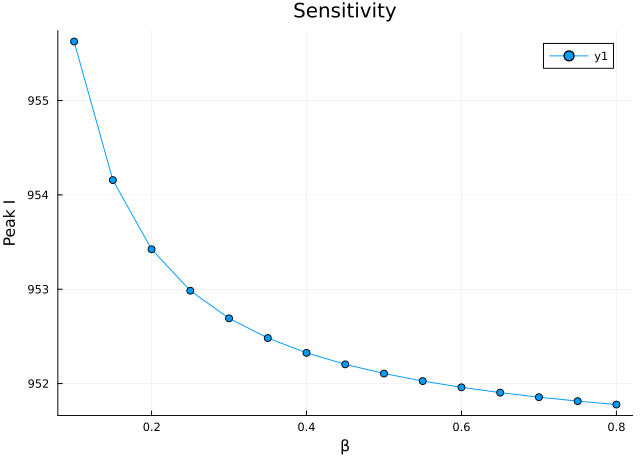

```julia
p2 = plot(
    df_scan.β,
    df_scan.peak_I,
    marker = :circle,
    xlabel = "β",
    ylabel = "Peak I",
    title = "Sensitivity",
)
savefig(plotsdir("sensitivity.png"))
if isinteractive()
    display(p2)
end

println("Отчётные графики сохранены в plots/")
p2
```

## 4.8 Анализ результатов

# 5 Выводы

Полученные навыки могут быть применены для моделирования и анализа других динамических систем, описываемых сетями Петри.

# Список литературы

1.

Petri C. A. Kommunikation mit Automaten: phdthesis. Bonn, Germany: Rheinische Friedrich-Wilhelms-Universität Bonn, 1962.

2.

Murata T. [Petri nets: Properties, analysis and applications](https://doi.org/10.1109/5.24143) // Proceedings of the IEEE. 1989. Т. 77, № 4. С. 541–580.

3.

Kermack W. O., McKendrick A. G. [A Contribution to the Mathematical Theory of Epidemics](https://doi.org/10.1098/rspa.1927.0118) // Proceedings of the Royal Society of London. Series A. 1927. Т. 115, № 772. С. 700–721.